# STATS 326/786

Assignment 01

```css
@import url('https://fonts.googleapis.com/css2?family=Lato:ital@1&display=swap');

h1, h2, h3, h4 {font-family: 'Lato', sans-serif;
    font-weight: bold}

body {font-family: 'Oswald', sans-serif;;
     background-color: #eff5f5}
```

**General comments:**

- All the plots should be labelled appropriately (axes, legends, titles). There will be marks allocated for this.
- Please submit both your `.Rmd`, and the generated output file `.html` or `.pdf` on Canvas before the due date/time.
- Please make sure that the `.Rmd` file compiles without any errors. The marker will not spend time fixing the bugs in your code.
- Please avoid specifying absolute paths.
- Your submission must be original, and if we recognize that you have copied answers from another student in the course, we will deduct your marks.
- You must use `tidyverse` packages to answer the questions in this assignment. Please use `dplyr` for data wrangling/manipulation, `ggplot2` for data visualisation, and `lubridate` for dates/times. Some parts of Problem 2 will use plots from the `fpp3` packages.
- IMPORTANT NOTE: There are some questions that are for STATS 786 only. Students taking STATS 326, while you are welcome to attempt these questions, please do not submit answers to them.

**Due: Friday 15 March 2023 at 16:00 PM (NZ time)**

# Problem 1: Kobe Bryant

The `lakers` data set (in the `lubridate` package) contains play-by-play statistics of each Los Angeles Lakers basketball game in the 2008-2009 regular season. It contains the following variables:

| Variable | Description |
| --- | --- |
| `date` | Date of the game |
| `opponent` | Name of the opposition team |
| `game_type` | Home or away game |
| `time` | Time remaining on the game clock in a given period (counting down from 12 minutes) |
| `period` | The period of play (most games have four quarters, each 12 minutes in duration, noting that some games go into a 5-minute duration overtime if tied at the end of regular play) |
| `etype` | The type of play made (e.g., shot, turnover, rebound) |
| `team` | Name of the NBA team the player who made the play belongs to |
| `player` | Name of the player that the play was made by |
| `result` | Whether they won or lost the game |
| `type` | A more detailed description of the type of play made |
| `x` | The $x$-coordinate on the field of play (in ft) |
| `y` | The $y$-coordinate on the field of play (in ft) |

> 1. 6 Marks
> - Read in the `lakers` data set and convert this into a `tibble` object.
> - Keep only the rows relating to Kobe Bryant. Name this object `kobe`.
> - Transform the `date` variable into a `lubridate` date format (noting that it is currently in integer format).
> - Shot location is given by `x` and `y`. The center of the hoop is located at the coordinates $(25, 5.25)$. Center the `x` and `y` variables to $(0, 0)$; you will want to overwrite `x` and `y` in your `kobe` data set.

```r
data(lakers)
lakers <- as_tibble(lakers)

kobe <- lakers %>% filter(player == "Kobe Bryant")

kobe$date <- ymd(kobe$date)

kobe$y <- kobe$y - 5.25
kobe$x <- kobe$x - 25
```

> 2. 6 Marks
> - Subset the `kobe` data set by only considering plays that are shot attempts (i.e., where `etype` is equal to `shot`). Name this new data set `kobe.shot`.
> - Make a scatter plot of the centered shot location, colouring the points by `result`. You should use the `geom_point` layer.
> - Set the transparency of the points to `alpha = 0.5`.
> - Use the default colour scheme, but reverse the colour order so that shots made is green(ish) and shots missed is red(ish). Hint: You can use `scale_colour_discrete` with an additional argument.

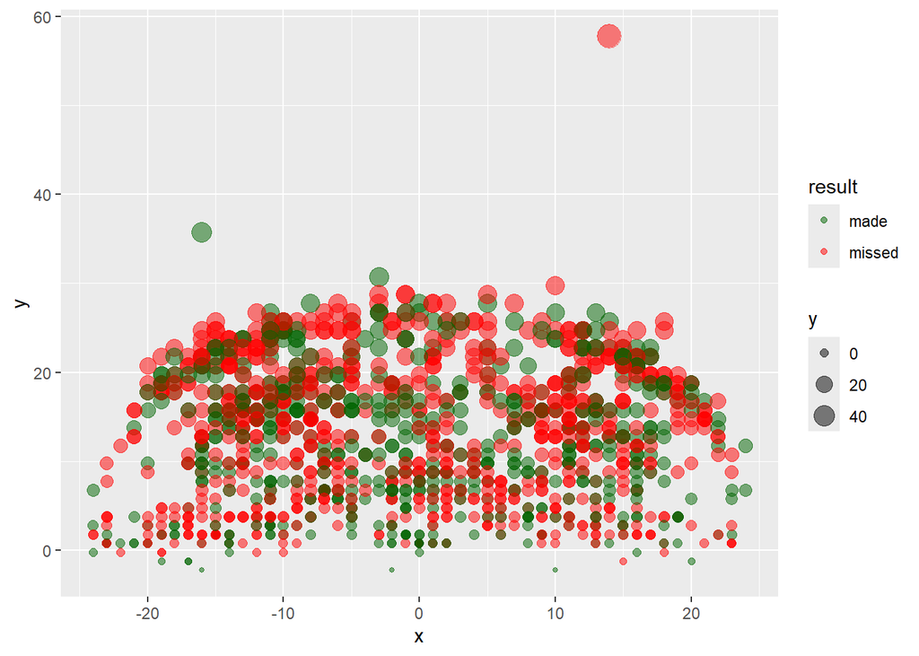

```r
kobe.shot <- kobe


kobe.shot <- subset(kobe.shot, etype == "shot")

ggplot(data = kobe.shot,
       mapping = aes(x = x,
                     y = y,
                     colour = result ,
                     size = y)) +

geom_point(alpha = 0.5) +
  scale_color_manual(values = c("made" = "dark green", "missed" = "red"))
```